# Analysis of Gene Signatures in DE Results

Theo Killian

2025-05-21

# Introduction

In order to understand the underlying biology of the DE genes generated from the earlier DESeq2 report, we will be comparing the significant DE genes to select gene signatures taken from the supplementary material found in [Karras, et al 2022](https://www.nature.com/articles/s41586-022-05242-7#Sec50). This report will generate volcano plots to visualize the expression of the melanoma gene signature genes, annotate the DE gene list with the melanoma gene signatures and perform custom GSEA to rank the enrichment of melanoma gene signature genes within the DE results using [fgsea](https://www.bioconductor.org/packages/devel/bioc/vignettes/fgsea/inst/doc/fgsea-tutorial.html).

## Read Signature File

The supplementary file containing DE gene lists on sheet 3 of the Excel file from [Karras, et al 2022](https://www.nature.com/articles/s41586-022-05242-7#Sec50) is read below:

```r
readxl::read_excel("./data/41586_2022_5242_MOESM3_ESM.xlsx",
                   sheet = 3,
                   skip = 2) %>%
  as.data.frame() -> sig_sheet_3

DT::datatable(sig_sheet_3)
```

|  | Stem-like | Neural Crest-like | Mesenchymal-like | RNA processing | Antigen Presentation | Stress-like (hypoxia) | Melanocytic (Oxphos) |
| --- | --- | --- | --- | --- | --- | --- | --- |
| 1 | Gtse1 | Tfap2b | Fap | Pabpn1 | Gbp4 | Bnip3 | Mlph |
| 2 | Cep170b | Prnp | Lama2 | Ccnl1 | Gbp6 | Tpi1 | Mitf |
| 3 | Tap1 | Mef2c | Prrx1 | Pnisr | Irf1 | Slc2a1 | Mlana |
| 4 | Ercc5 | Gfra1 | Slit3 | Sfpq | Nlrc5 | Mif | Pmel |
| 5 | Kank3 | Cd200 | Abi3bp | Ccnl2 | Stat2 | Vldlr | Slc45a2 |
| 6 | Rap2a | Syt11 | Loxl1 | Bclaf1 | Cd74 | Hk2 | Apoe |
| 7 | Ei24 | Thsd7a | Cdh11 | Hnrnpu | Il12rb1 | Vegfa | Dct |
| 8 | Zmat3 | Cxxc4 | Col6a3 | Rbm25 | B2m | Ldha | Gpnmb |
| 9 | Fas | Sema5a | Col6a2 | Luc7l2 | Gbp2 | Pfkl | Tyr |
| 10 | Igdcc4 | Tbx3 | Loxl2 | Ddx17 | Ifit3 | P4ha1 | Cited1 |

[output cut: 32 more lines]

## Annotate DE Genes with Melanoma Signature Genes

```r
res_data <- readRDS("./results/karthik_mice_obesity_DE_results_2025-05-18.rds")

sig_sheet_3 %>%
  tidyr::pivot_longer(
    cols = everything(),
    names_to = "signature",
    values_to = "gene_name") %>%
  dplyr::filter(!is.na(gene_name)) %>%
  as.data.frame() -> sig_list_long

res_data %>%
  dplyr::filter(!is.na(pvalue)) %>%
  dplyr::mutate(
    negLogP = -log10(pvalue),
    sig = ifelse(padj < 0.05 & abs(log2FoldChange) > 1,
                 "Significant", "Not Significant")) %>%
  dplyr::left_join(sig_list_long, by = "gene_name") %>%
  as.data.frame() -> res_data_annotated

res_data_annotated %>%
  dplyr::select(-c(contains("_rep"), contains("_id"), lfcSE, stat, sig, negLogP)) %>%
  dplyr::mutate(
    log2FoldChange = round(log2FoldChange, 3),
    baseMean       = round(baseMean, 1),
    pvalue         = signif(pvalue, 3),
    padj           = signif(padj, 3)) %>%
  dplyr::select(gene_name, signature, everything()) %>%
  as.data.frame() -> res_data_annotated_table

res_data_annotated_table %>%
  dplyr::filter(stringr::str_length(signature) > 1) %>%
  DT::datatable(
    options = list(pageLength = 10),
    caption = "Annotated Differential Expression Results of Melanoma Signature Genes: ")
```

|  | gene_name | signature | baseMean | log2FoldChange | pvalue | padj |
| --- | --- | --- | --- | --- | --- | --- |
| 1 | Fbn2 | Mesenchymal-like | 840 | 1.767 | 1.77e-24 | 2.63e-20 |
| 2 | Col1a1 | Mesenchymal-like | 14168.4 | 0.945 | 3.96e-06 | 0.00561 |
| 3 | Slit3 | Mesenchymal-like | 368.2 | 1.099 | 8.66e-05 | 0.0476 |
| 4 | Lama2 | Mesenchymal-like | 269 | 1.37 | 0.000415 | 0.0977 |
| 5 | Col5a2 | Mesenchymal-like | 15764.5 | 0.523 | 0.000629 | 0.121 |
| 6 | Col6a3 | Mesenchymal-like | 47067.7 | 0.661 | 0.00109 | 0.168 |
| 7 | Col3a1 | Mesenchymal-like | 94192.8 | 0.577 | 0.00244 | 0.251 |
| 8 | Kif26b | Neural Crest-like | 1436.5 | 0.746 | 0.00492 | 0.366 |
| 9 | Tfap2b | Neural Crest-like | 1799.1 | 0.731 | 0.00685 | 0.439 |
| 10 | Sema5a | Neural Crest-like | 14688.3 | 0.547 | 0.00688 | 0.439 |

[output cut: 186 more lines]

**Of all the genes in the signature lists, only 3 genes in the “Mesenchymal-like” gene list appear in the significant results, and all of them are higher in the “IgG” condition.**

```r
res_data_annotated_table %>%
  dplyr::filter(padj < 0.05,
                stringr::str_length(signature) > 1) %>%
  DT::datatable()
```

|  | gene_name | signature | baseMean | log2FoldChange | pvalue | padj |
| --- | --- | --- | --- | --- | --- | --- |
| 1 | Fbn2 | Mesenchymal-like | 840 | 1.767 | 1.77e-24 | 2.63e-20 |
| 2 | Col1a1 | Mesenchymal-like | 14168.4 | 0.945 | 3.96e-06 | 0.00561 |
| 3 | Slit3 | Mesenchymal-like | 368.2 | 1.099 | 8.66e-05 | 0.0476 |

We use the [fgsea](https://www.bioconductor.org/packages/devel/bioc/vignettes/fgsea/inst/doc/fgsea-tutorial.html) R package to perform GSEA on our custom melanoma signatures taken from the supplementary tables in Karras, et al 2022.

```r
mouse_biomart <- readRDS(file = "./data/mouse_biomart.rds")
sig_list_long %>%
  dplyr::left_join(mouse_biomart, by = "gene_name") %>%
  dplyr::filter(!is.na(gene_name),
                !is.na(entrez_id)) %>%
  dplyr::select(-ensembl_id) %>%
  dplyr::rename(SYMBOL = gene_name,
                ENTREZID = entrez_id) %>%
  as.data.frame() -> entrez_genes

readRDS(file = "./results/karthik_mice_obesity_DE_results_2025-05-18.rds") %>%
  dplyr::filter(
    !is.na(gene_name),
    !is.na(entrez_id),
    !duplicated(gene_name),
    !duplicated(entrez_id),
    !is.na(log2FoldChange),
    !is.na(pvalue)) %>%
  dplyr::arrange(desc(stat)) %>%
  dplyr::select(entrez_id, stat) %>%
  dplyr::rename(ENTREZID = entrez_id) %>%
  tibble::deframe() -> gene_list

list(
   entrez_genes %>%
    dplyr::filter(signature == unique(entrez_genes$signature)[1]) %>%
    dplyr::mutate(ENTREZID = as.character(ENTREZID)) %>%
    dplyr::pull(ENTREZID),
  entrez_genes %>%
    dplyr::filter(signature == unique(entrez_genes$signature)[2]) %>%
    dplyr::mutate(ENTREZID = as.character(ENTREZID)) %>%
    dplyr::pull(ENTREZID),
  entrez_genes %>%
    dplyr::filter(signature == unique(entrez_genes$signature)[3]) %>%
    dplyr::mutate(ENTREZID = as.character(ENTREZID)) %>%
    dplyr::pull(ENTREZID),
  entrez_genes %>%
    dplyr::filter(signature == unique(entrez_genes$signature)[4]) %>%
    dplyr::mutate(ENTREZID = as.character(ENTREZID)) %>%
    dplyr::pull(ENTREZID),
  entrez_genes %>%
    dplyr::filter(signature == unique(entrez_genes$signature)[5]) %>%
    dplyr::mutate(ENTREZID = as.character(ENTREZID)) %>%
    dplyr::pull(ENTREZID),
  entrez_genes %>%
    dplyr::filter(signature == unique(entrez_genes$signature)[6]) %>%
    dplyr::mutate(ENTREZID = as.character(ENTREZID)) %>%
    dplyr::pull(ENTREZID),
  entrez_genes %>%
    dplyr::filter(signature == unique(entrez_genes$signature)[7]) %>%
    dplyr::mutate(ENTREZID = as.character(ENTREZID)) %>%
    dplyr::pull(ENTREZID)) %>%
  setNames(unique(entrez_genes$signature)) -> melanoma_gene_sets

fgsea::fgsea(
  pathways = melanoma_gene_sets,
  stats = gene_list) %>%
  dplyr::arrange(padj) -> melanoma_gsea_res

melanoma_gsea_res %>%
  dplyr::mutate(
    log2err = round(log2err, 3),
    ES       = round(ES, 3),
    NES       = round(NES, 3),
    pval         = signif(pval, 3),
    padj           = signif(padj, 3)) %>%
  dplyr::select(-leadingEdge) %>%
  DT::datatable()
```

|  | pathway | pval | padj | log2err | ES | NES | size |
| --- | --- | --- | --- | --- | --- | --- | --- |
| 1 | Mesenchymal-like | 1.14e-11 | 7.98e-11 | 0.875 | 0.802 | 2.535 | 32 |
| 2 | Antigen Presentation | 0.00106 | 0.0037 | 0.455 | 0.544 | 1.823 | 41 |
| 3 | Neural Crest-like | 0.00596 | 0.0139 | 0.407 | 0.566 | 1.701 | 26 |
| 4 | Melanocytic (Oxphos) | 0.0402 | 0.0704 | 0.322 | -0.537 | -1.556 | 16 |
| 5 | Stem-like | 0.0935 | 0.131 | 0.183 | 0.413 | 1.357 | 38 |
| 6 | RNA processing | 0.128 | 0.149 | 0.162 | 0.454 | 1.32 | 23 |
| 7 | Stress-like (hypoxia) | 0.836 | 0.836 | 0.064 | -0.24 | -0.746 | 20 |

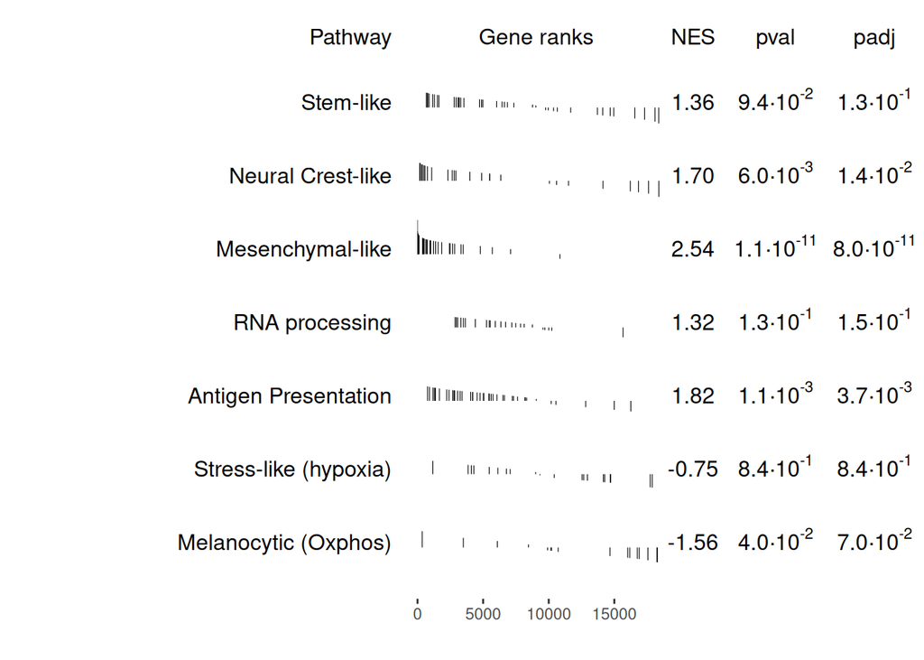

```r
plotGseaTable(melanoma_gene_sets, gene_list, melanoma_gsea_res,
              gseaParam=0.5)
```

## Volcano Plots

We will be visualizing the following gene signatures shown below in volcano plots to visually illustrate what the genes in these melanoma signature gene sets are expressing with respect to each condition.

### Standard Volcano Plot

A Volcano plot (log2 fold change vs -log10 p-value) helps identify genes that display large magnitude changes and high significance.

**NOTE: This is the same volcano plot from the previous DE analysis; it is displayed here purely for reference!**

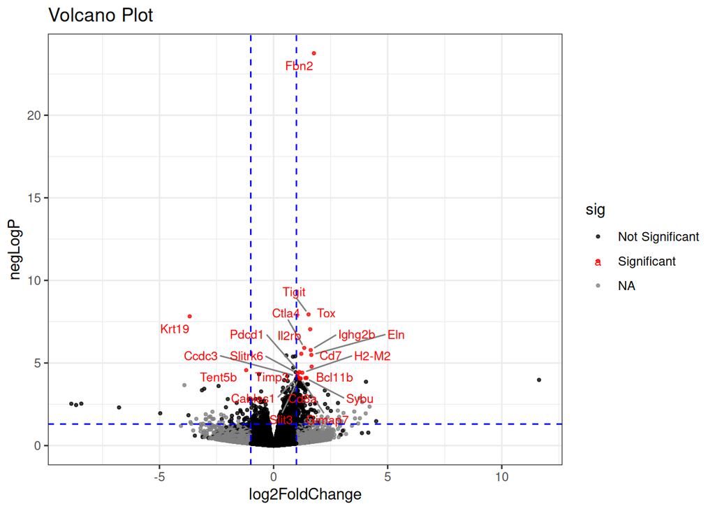

```r
res_data %>%
  dplyr::filter(!is.na(pvalue)) %>%
  dplyr::mutate(
    negLogP = -log10(pvalue),
    sig = ifelse(padj < 0.05 & abs(log2FoldChange) > 1,
                 "Significant", "Not Significant")) -> volcano_data
volcano_data %>%
  ggplot(aes(x = log2FoldChange, y = negLogP, color = sig)) +
  geom_point(size = 0.75, alpha = 0.75) +
  geom_text_repel(data = subset(volcano_data, sig == "Significant"),
                  aes(label = gene_name), size = 3, max.overlaps = Inf,
                  box.padding = 0.3, point.padding = 0.3, segment.color = "grey50") +
  scale_color_manual(values = c("Significant" = "red", "Not Significant" = "black")) +
  geom_hline(yintercept = -log10(0.05), color = "blue", linetype = "dashed") +
  geom_vline(xintercept = c(-1, 1), color = "blue", linetype = "dashed") +
  theme_bw() +
  ggtitle("Volcano Plot")
```

### Volcano Plot Highlighting “Stem-like” Genes

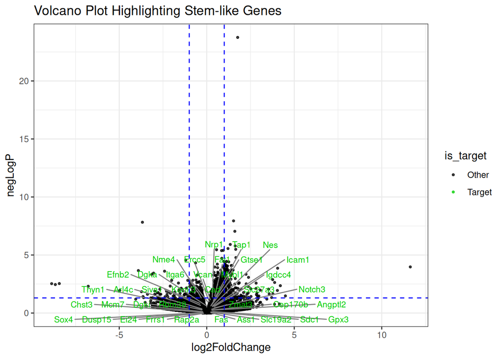

```r
sig_sheet_3 %>%
  dplyr::filter(!is.na(`Stem-like`)) %>%
  dplyr::pull(`Stem-like`) -> sig_list1

res_data %>%
  dplyr::filter(!is.na(pvalue)) %>%
  dplyr::mutate(
    negLogP = -log10(pvalue),
    sig = ifelse(padj < 0.05 & abs(log2FoldChange) > 1,
                 "Significant", "Not Significant"),
    is_target = ifelse(gene_name %in% sig_list1, "Target", "Other")) %>%
  as.data.frame() -> volcano_data

ggplot(volcano_data, aes(x = log2FoldChange, y = negLogP)) +
  geom_point(aes(color = is_target), size = 0.75, alpha = 0.75) +
  scale_color_manual(values = c("Target" = "green3", "Other" = "black")) +
  geom_text_repel(
    data = subset(volcano_data, is_target == "Target"),
    aes(label = gene_name),
    size = 3,
    max.overlaps = Inf,
    box.padding = 0.3,
    point.padding = 0.3,
    segment.color = "grey50",
    color = "green3") +
  geom_hline(yintercept = -log10(0.05), color = "blue", linetype = "dashed") +
  geom_vline(xintercept = c(-1, 1), color = "blue", linetype = "dashed") +
  theme_bw() +
  ggtitle(paste0("Volcano Plot Highlighting ", names(sig_sheet_3)[1], " Genes"))
```

### Volcano Plot Highlighting “Neural Crest-like” Genes

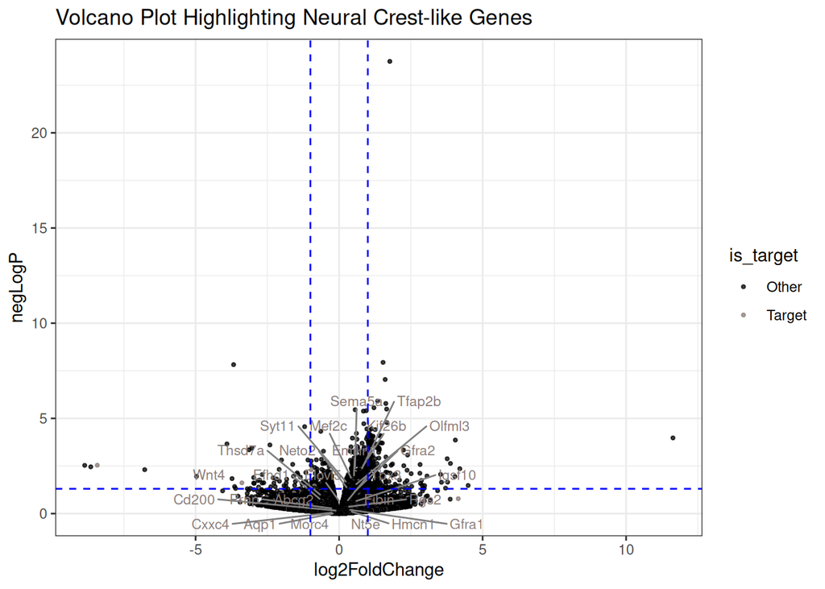

```r
sig_sheet_3 %>%
  dplyr::filter(!is.na(`Mesenchymal-like`)) %>%
  dplyr::pull(`Neural Crest-like`) -> sig_list2

res_data %>%
  dplyr::filter(!is.na(pvalue)) %>%
  dplyr::mutate(
    negLogP = -log10(pvalue),
    sig = ifelse(padj < 0.05 & abs(log2FoldChange) > 1,
                 "Significant", "Not Significant"),
    is_target = ifelse(gene_name %in% sig_list2, "Target", "Other")) %>%
  as.data.frame() -> volcano_data

ggplot(volcano_data, aes(x = log2FoldChange, y = negLogP)) +
  geom_point(aes(color = is_target), size = 0.75, alpha = 0.75) +
  scale_color_manual(values = c("Target" = "mistyrose4", "Other" = "black")) +
  geom_text_repel(
    data = subset(volcano_data, is_target == "Target"),
    aes(label = gene_name),
    size = 3,
    max.overlaps = Inf,
    box.padding = 0.3,
    point.padding = 0.3,
    segment.color = "grey50",
    color = "mistyrose4") +
  geom_hline(yintercept = -log10(0.05), color = "blue", linetype = "dashed") +
  geom_vline(xintercept = c(-1, 1), color = "blue", linetype = "dashed") +
  theme_bw() +
  ggtitle(paste0("Volcano Plot Highlighting ", names(sig_sheet_3)[2], " Genes"))
```

### Volcano Plot Highlighting “Mesenchymal-like” Genes

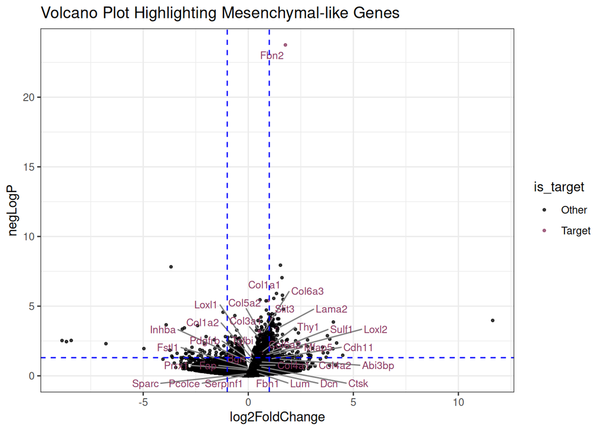

```r
sig_sheet_3 %>%
  dplyr::filter(!is.na(`Mesenchymal-like`)) %>%
  dplyr::pull(`Mesenchymal-like`) -> sig_list3

res_data %>%
  dplyr::filter(!is.na(pvalue)) %>%
  dplyr::mutate(
    negLogP = -log10(pvalue),
    sig = ifelse(padj < 0.05 & abs(log2FoldChange) > 1,
                 "Significant", "Not Significant"),
    is_target = ifelse(gene_name %in% sig_list3, "Target", "Other")) %>%
  as.data.frame() -> volcano_data

ggplot(volcano_data, aes(x = log2FoldChange, y = negLogP)) +
  geom_point(aes(color = is_target), size = 0.75, alpha = 0.75) +
  scale_color_manual(values = c("Target" = "hotpink4", "Other" = "black")) +
  geom_text_repel(
    data = subset(volcano_data, is_target == "Target"),
    aes(label = gene_name),
    size = 3,
    max.overlaps = Inf,
    box.padding = 0.3,
    point.padding = 0.3,
    segment.color = "grey50",
    color = "hotpink4") +
  geom_hline(yintercept = -log10(0.05), color = "blue", linetype = "dashed") +
  geom_vline(xintercept = c(-1, 1), color = "blue", linetype = "dashed") +
  theme_bw() +
  ggtitle(paste0("Volcano Plot Highlighting ", names(sig_sheet_3)[3], " Genes"))
```

### Volcano Plot Highlighting “RNA processing” Genes

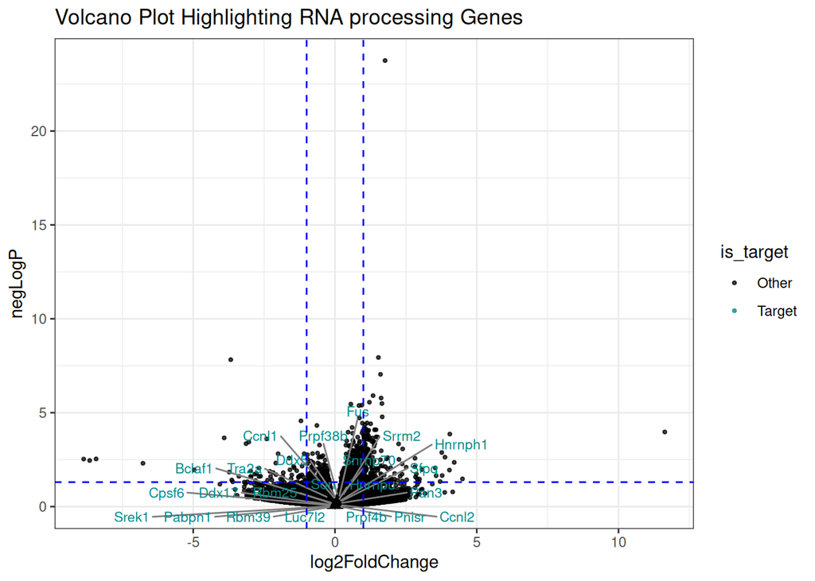

```r
sig_sheet_3 %>%
  dplyr::filter(!is.na(`RNA processing`)) %>%
  dplyr::pull(`RNA processing`) -> sig_list4

res_data %>%
  dplyr::filter(!is.na(pvalue)) %>%
  dplyr::mutate(
    negLogP = -log10(pvalue),
    sig = ifelse(padj < 0.05 & abs(log2FoldChange) > 1,
                 "Significant", "Not Significant"),
    is_target = ifelse(gene_name %in% sig_list4, "Target", "Other")) %>%
  as.data.frame() -> volcano_data

ggplot(volcano_data, aes(x = log2FoldChange, y = negLogP)) +
  geom_point(aes(color = is_target), size = 0.75, alpha = 0.75) +
  scale_color_manual(values = c("Target" = "#008B8B", "Other" = "black")) +
  geom_text_repel(
    data = subset(volcano_data, is_target == "Target"),
    aes(label = gene_name),
    size = 3,
    max.overlaps = Inf,
    box.padding = 0.3,
    point.padding = 0.3,
    segment.color = "grey50",
    color = "#008B8B") +
  geom_hline(yintercept = -log10(0.05), color = "blue", linetype = "dashed") +
  geom_vline(xintercept = c(-1, 1), color = "blue", linetype = "dashed") +
  theme_bw() +
  ggtitle(paste0("Volcano Plot Highlighting ", names(sig_sheet_3)[4], " Genes"))
```

### Volcano Plot Highlighting “Antigen Presentation” Genes

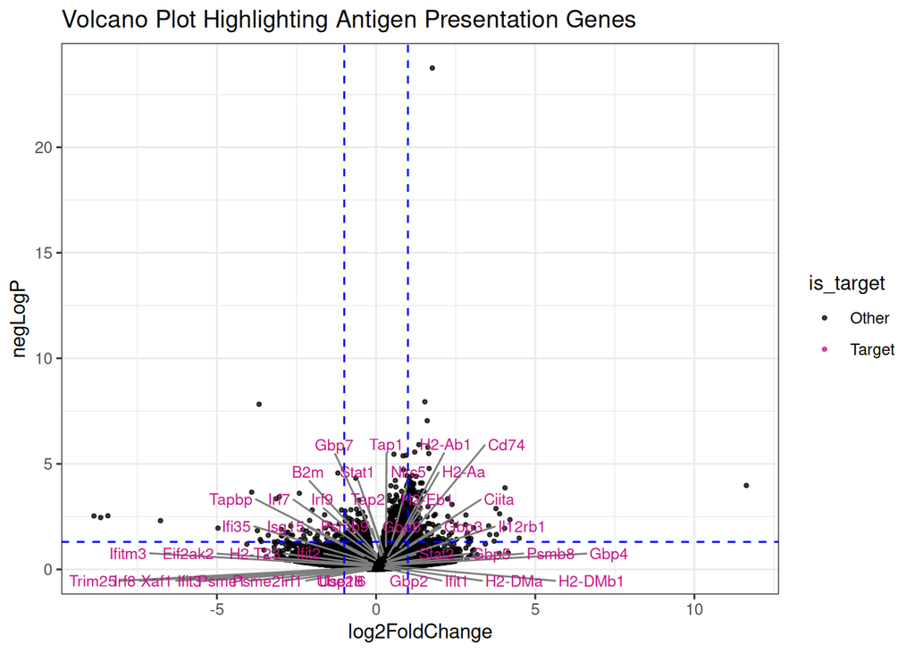

```r
sig_sheet_3 %>%
  dplyr::filter(!is.na(`Antigen Presentation`)) %>%
  dplyr::pull(`Antigen Presentation`) -> sig_list5

res_data %>%
  dplyr::filter(!is.na(pvalue)) %>%
  dplyr::mutate(
    negLogP = -log10(pvalue),
    sig = ifelse(padj < 0.05 & abs(log2FoldChange) > 1,
                 "Significant", "Not Significant"),
    is_target = ifelse(gene_name %in% sig_list5, "Target", "Other")) %>%
  as.data.frame() -> volcano_data

ggplot(volcano_data, aes(x = log2FoldChange, y = negLogP)) +
  geom_point(aes(color = is_target), size = 0.75, alpha = 0.75) +
  scale_color_manual(values = c("Target" = "#C71585", "Other" = "black")) +
  geom_text_repel(
    data = subset(volcano_data, is_target == "Target"),
    aes(label = gene_name),
    size = 3,
    max.overlaps = Inf,
    box.padding = 0.3,
    point.padding = 0.3,
    segment.color = "grey50",
    color = "#C71585") +
  geom_hline(yintercept = -log10(0.05), color = "blue", linetype = "dashed") +
  geom_vline(xintercept = c(-1, 1), color = "blue", linetype = "dashed") +
  theme_bw() +
  ggtitle(paste0("Volcano Plot Highlighting ", names(sig_sheet_3)[5], " Genes"))
```

[figure not shown]

```r
sig_sheet_3 %>%
  dplyr::filter(!is.na(`Stem-like`)) %>%
  dplyr::pull(`Stem-like`) -> sig_list6

res_data %>%
  dplyr::filter(!is.na(pvalue)) %>%
  dplyr::mutate(
    negLogP = -log10(pvalue),
    sig = ifelse(padj < 0.05 & abs(log2FoldChange) > 1,
                 "Significant", "Not Significant"),
    is_target = ifelse(gene_name %in% sig_list6, "Target", "Other")) %>%
  as.data.frame() -> volcano_data

ggplot(volcano_data, aes(x = log2FoldChange, y = negLogP)) +
  geom_point(aes(color = is_target), size = 0.75, alpha = 0.75) +
  scale_color_manual(values = c("Target" = "#B22222", "Other" = "black")) +
  geom_text_repel(
    data = subset(volcano_data, is_target == "Target"),
    aes(label = gene_name),
    size = 3,
    max.overlaps = Inf,
    box.padding = 0.3,
    point.padding = 0.3,
    segment.color = "grey50",
    color = "#B22222") +
  geom_hline(yintercept = -log10(0.05), color = "blue", linetype = "dashed") +
  geom_vline(xintercept = c(-1, 1), color = "blue", linetype = "dashed") +
  theme_bw() +
  ggtitle(paste0("Volcano Plot Highlighting ", names(sig_sheet_3)[6], " Genes"))
```

### Volcano Plot Highlighting “Melanocytic (Oxphos)” Genes

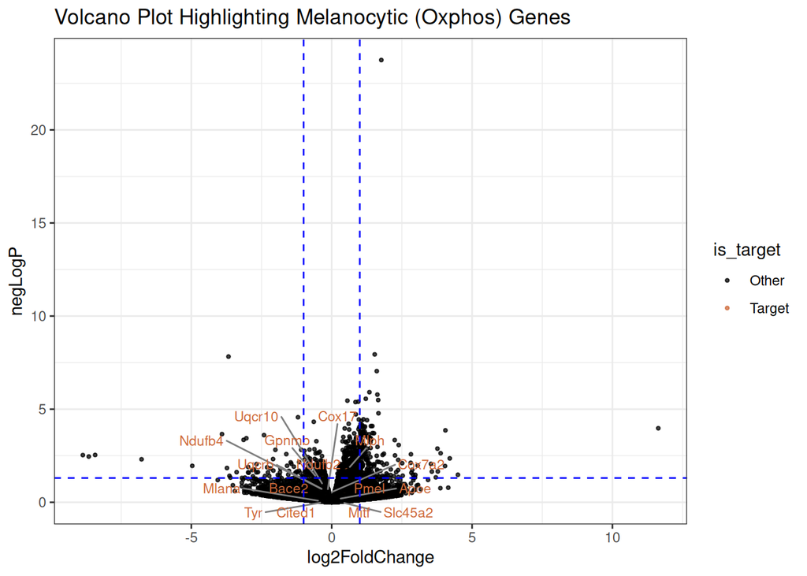

```r
sig_sheet_3 %>%
  dplyr::filter(!is.na(`Melanocytic (Oxphos)`)) %>%
  dplyr::pull(`Melanocytic (Oxphos)`) -> sig_list7

res_data %>%
  dplyr::filter(!is.na(pvalue)) %>%
  dplyr::mutate(
    negLogP = -log10(pvalue),
    sig = ifelse(padj < 0.05 & abs(log2FoldChange) > 1,
                 "Significant", "Not Significant"),
    is_target = ifelse(gene_name %in% sig_list7, "Target", "Other")) %>%
  as.data.frame() -> volcano_data

ggplot(volcano_data, aes(x = log2FoldChange, y = negLogP)) +
  geom_point(aes(color = is_target), size = 0.75, alpha = 0.75) +
  scale_color_manual(values = c("Target" = "sienna3", "Other" = "black")) +
  geom_text_repel(
    data = subset(volcano_data, is_target == "Target"),
    aes(label = gene_name),
    size = 3,
    max.overlaps = Inf,
    box.padding = 0.3,
    point.padding = 0.3,
    segment.color = "grey50",
    color = "sienna3") +
  geom_hline(yintercept = -log10(0.05), color = "blue", linetype = "dashed") +
  geom_vline(xintercept = c(-1, 1), color = "blue", linetype = "dashed") +
  theme_bw() +
  ggtitle(paste0("Volcano Plot Highlighting ", names(sig_sheet_3)[7], " Genes"))
```

## Saving Outputs

The results are saved as `.rds` and `.xlsx` files for downstream use:

```r
## save table of melanoma GSEA results
write_xlsx(x = melanoma_gsea_res,
           path = paste0("./results/", project_name, "_melanoma_signature_GSEA_results_",
                         Sys.Date(), ".xlsx"))

# Save DE result object
saveRDS(object = res_data_annotated,
        file = paste0("./results/", project_name, "_DE_results_annotated_",
                      Sys.Date(), ".rds"))

# Save an Excel file
write_xlsx(x = res_data_annotated,
           path = paste0("./results/", project_name, "_DE_results_annotated_",
                         Sys.Date(), ".xlsx"))
```